# Ford GoBike System Data Exploration

> *by Mohamed BOUSETTA MAHJOUB*

## Preliminary Wrangling

> This data set includes information about individual rides made in a bike-sharing system covering the greater San Francisco Bay area.

```python
# import all packages and set plots to be embedded inline
import numpy as np
import pandas as pd
import matplotlib.pyplot as plt
import seaborn as sb

%matplotlib inline
```

```python
#suppress python warnings
import warnings
warnings.filterwarnings('ignore')
```

### Ghathering

```python
# load in the dataset into a pandas dataframe
df = pd.read_csv('201902-fordgobike-tripdata.csv')
df.head()
```

|  | duration_sec | start_time | end_time | start_station_id | start_station_name | start_station_latitude | start_station_longitude | end_station_id | end_station_name | end_station_latitude | end_station_longitude | bike_id | user_type | member_birth_year | member_gender | bike_share_for_all_trip |
| --- | --- | --- | --- | --- | --- | --- | --- | --- | --- | --- | --- | --- | --- | --- | --- | --- |
| 0 | 52185 | 2019-02-28 17:32:10.1450 | 2019-03-01 08:01:55.9750 | 21.0 | Montgomery St BART Station (Market St at 2nd St) | 37.789625 | -122.400811 | 13.0 | Commercial St at Montgomery St | 37.794231 | -122.402923 | 4902 | Customer | 1984.0 | Male | No |
| 1 | 42521 | 2019-02-28 18:53:21.7890 | 2019-03-01 06:42:03.0560 | 23.0 | The Embarcadero at Steuart St | 37.791464 | -122.391034 | 81.0 | Berry St at 4th St | 37.775880 | -122.393170 | 2535 | Customer | NaN | NaN | No |
| 2 | 61854 | 2019-02-28 12:13:13.2180 | 2019-03-01 05:24:08.1460 | 86.0 | Market St at Dolores St | 37.769305 | -122.426826 | 3.0 | Powell St BART Station (Market St at 4th St) | 37.786375 | -122.404904 | 5905 | Customer | 1972.0 | Male | No |
| 3 | 36490 | 2019-02-28 17:54:26.0100 | 2019-03-01 04:02:36.8420 | 375.0 | Grove St at Masonic Ave | 37.774836 | -122.446546 | 70.0 | Central Ave at Fell St | 37.773311 | -122.444293 | 6638 | Subscriber | 1989.0 | Other | No |
| 4 | 1585 | 2019-02-28 23:54:18.5490 | 2019-03-01 00:20:44.0740 | 7.0 | Frank H Ogawa Plaza | 37.804562 | -122.271738 | 222.0 | 10th Ave at E 15th St | 37.792714 | -122.248780 | 4898 | Subscriber | 1974.0 | Male | Yes |

### Assessing

```python
df.shape
```

```
(183412, 16)
```

```python
df.info()
```

```
<class 'pandas.core.frame.DataFrame'>
RangeIndex: 183412 entries, 0 to 183411
Data columns (total 16 columns):
 #   Column                   Non-Null Count   Dtype
---  ------                   --------------   -----
 0   duration_sec             183412 non-null  int64
 1   start_time               183412 non-null  object
 2   end_time                 183412 non-null  object
 3   start_station_id         183215 non-null  float64
 4   start_station_name       183215 non-null  object
 5   start_station_latitude   183412 non-null  float64
 6   start_station_longitude  183412 non-null  float64
 7   end_station_id           183215 non-null  float64
 8   end_station_name         183215 non-null  object
 9   end_station_latitude     183412 non-null  float64
 10  end_station_longitude    183412 non-null  float64
 11  bike_id                  183412 non-null  int64
 12  user_type                183412 non-null  object
 13  member_birth_year        175147 non-null  float64
 14  member_gender            175147 non-null  object
 15  bike_share_for_all_trip  183412 non-null  object
dtypes: float64(7), int64(2), object(7)
memory usage: 22.4+ MB
```

```python
df.duplicated().sum()
```

```
0
```

```python
df.member_gender.value_counts()
```

```
Male      130651
Female     40844
Other       3652
Name: member_gender, dtype: int64
```

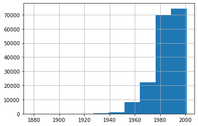

```python
df.member_birth_year.hist()
```

```python
df.describe()
```

|  | duration_sec | start_station_id | start_station_latitude | start_station_longitude | end_station_id | end_station_latitude | end_station_longitude | bike_id | member_birth_year |
| --- | --- | --- | --- | --- | --- | --- | --- | --- | --- |
| count | 183412.000000 | 183215.000000 | 183412.000000 | 183412.000000 | 183215.000000 | 183412.000000 | 183412.000000 | 183412.000000 | 175147.000000 |
| mean | 726.078435 | 138.590427 | 37.771223 | -122.352664 | 136.249123 | 37.771427 | -122.352250 | 4472.906375 | 1984.806437 |
| std | 1794.389780 | 111.778864 | 0.099581 | 0.117097 | 111.515131 | 0.099490 | 0.116673 | 1664.383394 | 10.116689 |
| min | 61.000000 | 3.000000 | 37.317298 | -122.453704 | 3.000000 | 37.317298 | -122.453704 | 11.000000 | 1878.000000 |
| 25% | 325.000000 | 47.000000 | 37.770083 | -122.412408 | 44.000000 | 37.770407 | -122.411726 | 3777.000000 | 1980.000000 |
| 50% | 514.000000 | 104.000000 | 37.780760 | -122.398285 | 100.000000 | 37.781010 | -122.398279 | 4958.000000 | 1987.000000 |
| 75% | 796.000000 | 239.000000 | 37.797280 | -122.286533 | 235.000000 | 37.797320 | -122.288045 | 5502.000000 | 1992.000000 |
| max | 85444.000000 | 398.000000 | 37.880222 | -121.874119 | 398.000000 | 37.880222 | -121.874119 | 6645.000000 | 2001.000000 |

**Assessing Summary**

### Cleaning Data

```python
df_clean = df.copy()
```

```python
# drop NAN Values
df_clean.dropna(inplace=True)
```

```python
# check non-null
df_clean.info()
```

```
<class 'pandas.core.frame.DataFrame'>
Int64Index: 174952 entries, 0 to 183411
Data columns (total 16 columns):
 #   Column                   Non-Null Count   Dtype
---  ------                   --------------   -----
 0   duration_sec             174952 non-null  int64
 1   start_time               174952 non-null  object
 2   end_time                 174952 non-null  object
 3   start_station_id         174952 non-null  float64
 4   start_station_name       174952 non-null  object
 5   start_station_latitude   174952 non-null  float64
 6   start_station_longitude  174952 non-null  float64
 7   end_station_id           174952 non-null  float64
 8   end_station_name         174952 non-null  object
 9   end_station_latitude     174952 non-null  float64
 10  end_station_longitude    174952 non-null  float64
 11  bike_id                  174952 non-null  int64
 12  user_type                174952 non-null  object
 13  member_birth_year        174952 non-null  float64
 14  member_gender            174952 non-null  object
 15  bike_share_for_all_trip  174952 non-null  object
dtypes: float64(7), int64(2), object(7)
memory usage: 22.7+ MB
```

```python
# convert member_birth_year type to integer
df_clean['member_birth_year'] = df_clean['member_birth_year'].astype(int)
```

```python
# check member_birth_year type
df_clean['member_birth_year'].dtypes
```

```
dtype('int64')
```

```python
# convert bike_id type to string
df_clean['bike_id'] = df_clean['bike_id'].astype(str)
```

```python
# check bike_id type
df_clean['bike_id'].dtypes
```

```
dtype('O')
```

```python
# convert start_station_id type to string
df_clean['start_station_id'] = df_clean['start_station_id'].astype(int).astype(str)
```

```python
# check start_station_id type
df_clean['start_station_id'].dtypes
```

```
dtype('O')
```

```python
# convert end_station_id to string
df_clean['end_station_id'] = df_clean['end_station_id'].astype(int).astype(str)
```

```python
# check end_station_id type
df_clean['end_station_id'].dtypes
```

```
dtype('O')
```

```python
# convert start_time type to datetime
df_clean['start_time'] = pd.to_datetime(df_clean['start_time'])
```

```python
# check start_time type
df_clean['start_time'].dtypes
```

```
dtype('<M8[ns]')
```

```python
# convert end_time type
df_clean['end_time'] = pd.to_datetime(df_clean['end_time'])
```

```python
# check end_time type
df_clean['end_time'].dtypes
```

```
dtype('<M8[ns]')
```

```python
# extract start_year from start_time
df_clean['start_year'] = df_clean['start_time'].dt.year
# extract start_month from start_time
df_clean['start_month'] = df_clean['start_time'].dt.month
# extract start_day from start_time
df_clean['start_day'] = df_clean['start_time'].dt.day
# extract start_day_week from start_time
df_clean['start_day_week'] = df_clean['start_time'].dt.strftime("%A")
# extract start_hour from start_time
df_clean['start_hour'] = df_clean['start_time'].dt.hour
```

```python
# calculate member_age
df_clean['member_age'] = df_clean['start_year'] - df_clean['member_birth_year']
```

```python
# member_age distribution
df_clean.describe().member_age
```

```
count    174952.000000
mean         34.196865
std          10.118731
min          18.000000
25%          27.000000
50%          32.000000
75%          39.000000
max         141.000000
Name: member_age, dtype: float64
```

```python
# Bin edges that will be used to "cut" the data into age groups
bin_edges = [df_clean.member_age.min(), 24, 34, 64, df_clean.member_age.max() ]
# Labels for the four age groups
bin_names = ['Youth', 'Young Adults', 'Adults', 'Seniors']
# Creates age_groups column
df_clean['age_groups'] = pd.cut(df_clean['member_age'], bin_edges, labels=bin_names)
```

```python
# age_distribution distribution
df_clean['age_groups'].value_counts()
```

```
Young Adults    84513
Adults          65805
Youth           22920
Seniors          1680
Name: age_groups, dtype: int64
```

```python
df_clean.info()
```

```
<class 'pandas.core.frame.DataFrame'>
Int64Index: 174952 entries, 0 to 183411
Data columns (total 23 columns):
 #   Column                   Non-Null Count   Dtype
---  ------                   --------------   -----
 0   duration_sec             174952 non-null  int64
 1   start_time               174952 non-null  datetime64[ns]
 2   end_time                 174952 non-null  datetime64[ns]
 3   start_station_id         174952 non-null  object
 4   start_station_name       174952 non-null  object
 5   start_station_latitude   174952 non-null  float64
 6   start_station_longitude  174952 non-null  float64
 7   end_station_id           174952 non-null  object
 8   end_station_name         174952 non-null  object
 9   end_station_latitude     174952 non-null  float64
 10  end_station_longitude    174952 non-null  float64
 11  bike_id                  174952 non-null  object
 12  user_type                174952 non-null  object
 13  member_birth_year        174952 non-null  int64
 14  member_gender            174952 non-null  object
 15  bike_share_for_all_trip  174952 non-null  object
 16  start_year               174952 non-null  int64
 17  start_month              174952 non-null  int64
 18  start_day                174952 non-null  int64
 19  start_day_week           174952 non-null  object
 20  start_hour               174952 non-null  int64
 21  member_age               174952 non-null  int64
 22  age_groups               174918 non-null  category
dtypes: category(1), datetime64[ns](2), float64(4), int64(7), object(9)
memory usage: 30.9+ MB
```

### What is the structure of your dataset?

> - The original dataset contains 183412 observations (rides) and 16 features (duration_sec', 'start_time', 'end_time', 'start_station_id'...). After cleaning Data, we have deleted 8460 observations (missing Data) and added 7 features extracted from the original features (start_year', 'start_month', 'start_day', 'start_day_week', 'start_hour', 'member_age', 'age_groups').
> - The final dataset contains 174952 rides and 23 features.

### What is/are the main feature(s) of interest in your dataset?

> I'm most interested in figuring out :
> - Distribution of number of rides : what features have effect on number of rides
> - What features are best for predicting the duration of ride in the dataset

### What features in the dataset do you think will help support your investigation into your feature(s) of interest?

> I think features like user_type', 'member_gender , member age, start_hour, start_day can be helpful for our investigation.

## Univariate Exploration

### Distribution of number of rides

> I'll start by looking at the distribution of the number of rides by :
> - Gender
> - User type
> - age
> - Start day & hour

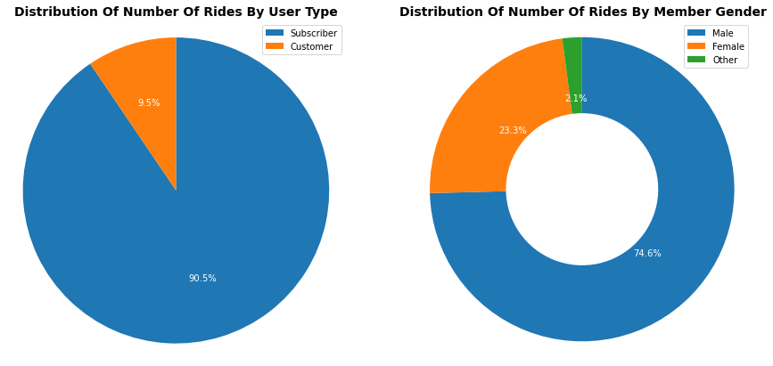

```python
plt.figure(figsize = [15, 8])

# first plot : number of rides for each user_type
plt.subplot(1, 2, 1)
user_type = df_clean.user_type.value_counts()
plt.pie(user_type, labels = user_type.index, startangle = 90, autopct= '%1.1f%%',
        counterclock = False, textprops={'color':'white'});
plt.axis('square')
plt.title('Distribution of number of rides by user type'.title(), fontsize=14, weight='bold')
plt.legend()

# second plot : number of rides for each member_gender
plt.subplot(1, 2, 2)
sorted_counts = df_clean.member_gender.value_counts()
plt.pie(sorted_counts, labels = sorted_counts.index, startangle = 90, autopct= '%1.1f%%',
        counterclock = False, textprops={'color':'white'}, wedgeprops = {'width' : 0.5});
plt.axis('square')
plt.title('Distribution of number of rides by member gender'.title(), fontsize=14, weight='bold')
plt.legend()

plt.show()
```

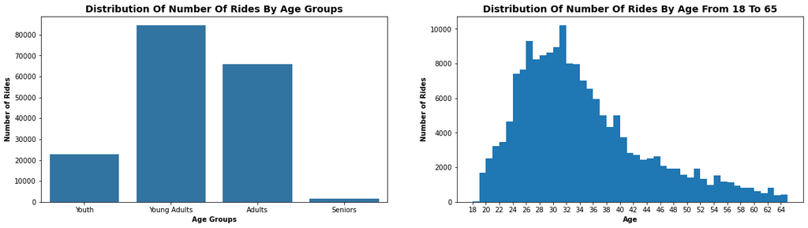

```python
plt.figure(figsize = [20, 5])
base_color = sb.color_palette()[0]
# first plot : number of rides for each age group
plt.subplot(1, 2, 1)
sb.countplot(data=df_clean, x='age_groups', color=base_color)
plt.xlabel('Age Groups', fontsize=10, weight='bold')
plt.ylabel('Number of Rides' , fontsize=10, weight='bold')
plt.title('Distribution of number of rides by Age Groups'.title(), fontsize=14, weight='bold')
# second plot : histogram of member age from 18 to 65
plt.subplot(1, 2, 2)
bins = np.arange(18, 66, 1)
plt.hist(data = df_clean, x = 'member_age', bins = bins)
plt.xticks(np.arange(18, 66, 2));
plt.xlabel('Age', fontsize=10, weight='bold')
plt.ylabel('Number of Rides' , fontsize=10, weight='bold')
plt.title('Distribution of number of rides by Age from 18 to 65'.title(), fontsize=14, weight='bold')

plt.show()
```

> locking at the charts above, we find that :
> - Most riders were male
> - Most riders were subscribers
> - Most members were young adults (25-34 years old) espacially 31 years old.

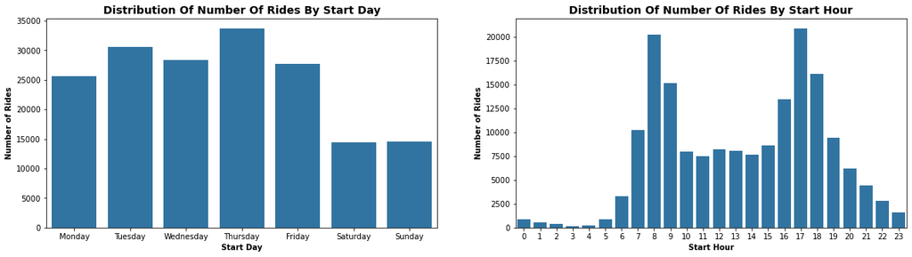

```python
plt.figure(figsize = [20, 5])
base_color = sb.color_palette()[0]
# first plot : number of rides on each satr day of the week
plt.subplot(1, 2, 1)
order = ['Monday', 'Tuesday', 'Wednesday', 'Thursday', 'Friday', 'Saturday', 'Sunday']
sb.countplot(data=df_clean, x='start_day_week', color=base_color, order= order)
plt.xlabel('Start Day', fontsize=10, weight='bold')
plt.ylabel('Number of Rides' , fontsize=10, weight='bold')
plt.title('Distribution of number of rides by start day'.title(), fontsize=14, weight='bold')
# second plot : number of rides at each start hour of the day
plt.subplot(1, 2, 2)
sb.countplot(data=df_clean, x='start_hour', color=base_color)
plt.xlabel('Start Hour', fontsize=10, weight='bold')
plt.ylabel('Number of Rides' , fontsize=10, weight='bold')
plt.title('Distribution of number of rides by start hour'.title(), fontsize=14, weight='bold')

plt.show()
```

> Locking at the charts above, we find that the trip distribution over day hours peaks around two timeframes, 7am-10am and 16pm-19pm, during typical rush hours. Looking in combined with the trip distribution over day of week plot, it is quite obvious that the majority of rides happened on work days (Mon-Fri).

### What features are best for predicting the duration of ride in the dataset ?

In this section, I'll be interested of the distribution of ride duration.

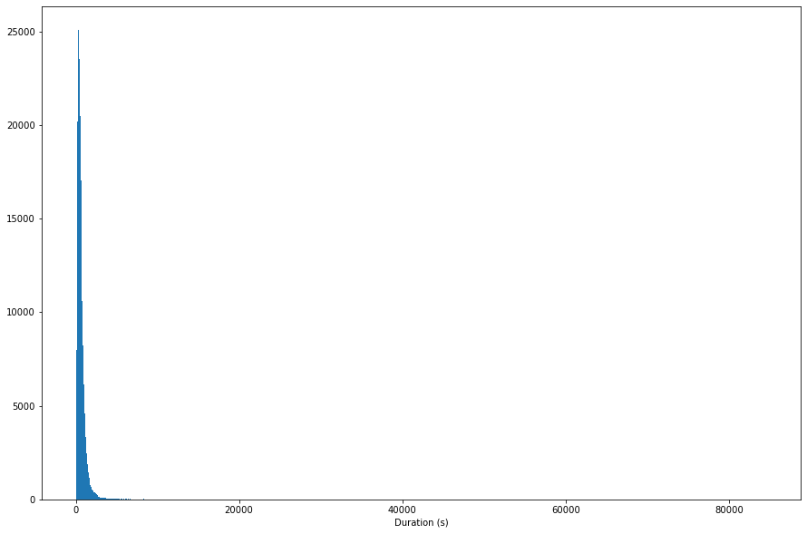

```python
# start with a standard-scaled plot
plt.figure(figsize=[15, 10])
binsize = 100
bins = np.arange(df_clean['duration_sec'].min(), df_clean['duration_sec'].max()+binsize, binsize)
# plot histogram of duration
plt.hist(data = df_clean, x = 'duration_sec', bins = bins)
plt.xlabel('Duration (s)')
plt.show()
```

> We can see that there are some outliers in the high end of duration, so we need to take a deeper look and clean these outliers.

> Let's first calculate the interquartile range (IQR) to find the ouliers list.

```python
# statistics of duration_sec variable
df_clean.describe().duration_sec
```

```
count    174952.000000
mean        704.002744
std        1642.204905
min          61.000000
25%         323.000000
50%         510.000000
75%         789.000000
max       84548.000000
Name: duration_sec, dtype: float64
```

```python
def find_outliers(df, col):
    '''
    This function will calculate outliers limits using interquartile range IQR
    Inputs :
     - df : pandas DataFrame
     - col : column name, type string
     Outputs:
     - tuple of float, contains low and high limits, None if doesn't exist
    '''
    Q1 = df[col].quantile(0.25)
    Q3 = df[col].quantile(0.75)
    IQR = Q3 - Q1
    high_limit = Q3 + IQR*1.5
    low_limit = Q1 - IQR*1.5
    if high_limit >= df[col].max():
        high_limit = None
    if low_limit <= df[col].min():
        low_limit = None
    return low_limit, high_limit
```

```python
# calculate outliers limits using find_outliers function
print(find_outliers(df_clean, 'duration_sec'))
```

```
(None, 1488.0)
```

```python
limit_ouliers = find_outliers(df_clean, 'duration_sec')[1]
```

```python
# number of ouliers
df_clean.query(f'duration_sec > {limit_ouliers}').shape[0]
```

```
9328
```

```python
# proportion of ouliers
100*df_clean.query(f'duration_sec > {limit_ouliers}').shape[0]/df_clean.shape[0]
```

```
5.331748136631762
```

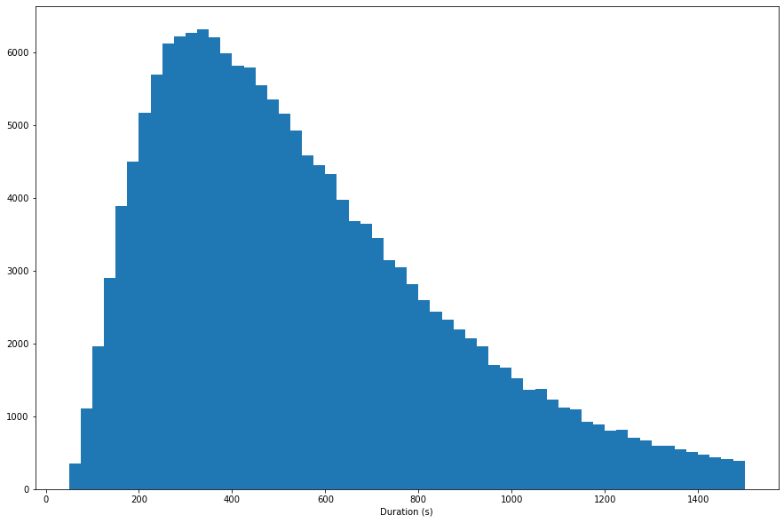

```python
# plot duration hist without outliers
plt.figure(figsize=[15, 10])
binsize = 25
bins = np.arange(50, limit_ouliers+binsize, binsize)
plt.hist(data = df_clean, x = 'duration_sec', bins = bins)
plt.xlabel('Duration (s)')
plt.show()
```

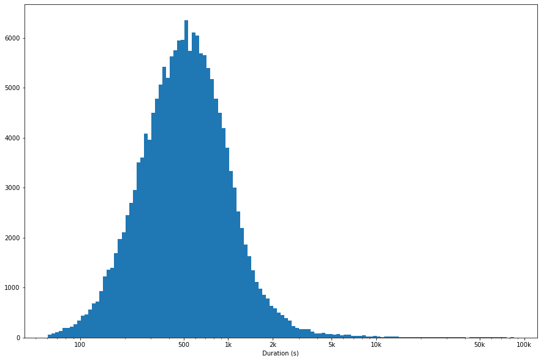

```python
# there's a long tail in the distribution, so let's put it on a log scale instead
log_binsize = 0.025
bins = 10 ** np.arange(1.78, np.log10(df_clean['duration_sec'].max())+log_binsize, log_binsize)
plt.figure(figsize=[15, 10])
#plot histogram of log duration with outliers
plt.hist(data = df_clean, x = 'duration_sec', bins = bins)
plt.xscale('log')
plt.xticks([100, 500, 1e3, 2e3, 5e3, 1e4, 5e4, 1e5], [100, 500, '1k', '2k','5k', '10k', '50k', '100k'])
plt.xlabel('Duration (s)')
plt.show()
```

> log-scale chart shows that there are some outliers in the high end of log duration.

> we will do the same steps as standard-scaled plot to find outliers points for log-scaled plot

```python
# create log duration column
df_clean['duration_log'] = np.log10(df_clean.duration_sec)
# statistics of log duration
df_clean.duration_log.describe()
```

```
count    174952.000000
mean          2.707824
std           0.305190
min           1.785330
25%           2.509203
50%           2.707570
75%           2.897077
max           4.927103
Name: duration_log, dtype: float64
```

```python
# calculate outliers limits using find_outliers function
print(find_outliers(df_clean, 'duration_log'))
```

```
(1.9273908010136271, 3.478888724526896)
```

```python
low_limit_ouliers, high_limit_ouliers = find_outliers(df_clean, 'duration_log')
```

```python
# number of log outliers
n_outliers = df_clean[(df_clean.duration_log < low_limit_ouliers) | (df_clean.duration_log > high_limit_ouliers)].shape[0]
print(n_outliers)
```

```
2637
```

```python
# proportion of ouliers
100*n_outliers/df_clean.duration_log.shape[0]
```

```
1.5072705656408616
```

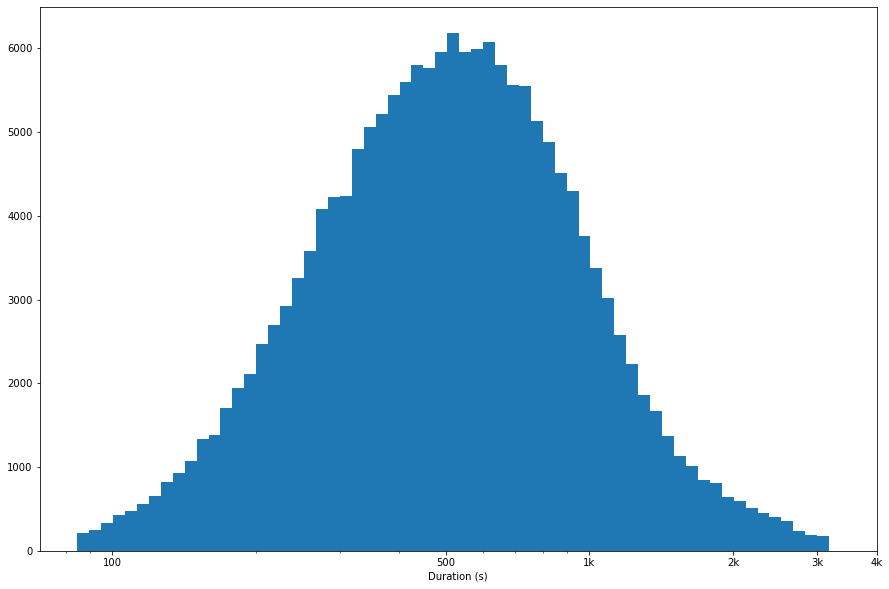

```python
#plot histogram of log duration without outliers
log_binsize = 0.025
bins = 10 ** np.arange(low_limit_ouliers, high_limit_ouliers+log_binsize, log_binsize)

plt.figure(figsize=[15, 10])
plt.hist(data = df_clean, x = 'duration_sec', bins = bins)
plt.xscale('log')
plt.xticks([100, 500, 1e3, 2e3, 3e3, 4e3], [100, 500, '1k', '2k','3k', '4k'])
plt.xlabel('Duration (s)')
plt.show()
```

> - Duration has a long-tailed distribution, with a lot of rides on the low duration end, and few on the high duration end. the proportion of outliers is 5.33%, that means 94.67% of rides were less than 1488s
> - When plotted on a log-scale, the duration distribution looks like normal distribution, with one peak aroud 500s. we could reduce the proportion of outliers to 1.5%.

### Discuss the distribution(s) of your variable(s) of interest. Were there any unusual points? Did you need to perform any transformations?

> - There were more male riders than female, and most members were subscribers compared to casual riders. The majority of the members young adults ( 25 to 34 years old).
> - The number of trips peaked around 7-10am and 16-19pm during a day (rush hours), there were more trips on work days (Mon-Fri) compared to weekends : Primary usage is probably for going to work.
> - Most rides were quick and short, lasted between 5 to 10 minutes, though there were some very long outliers like 24hrs
> - the log-scale distribution shows that rides were normaly distributed with a peak aroud 500s

### Of the features you investigated, were there any unusual distributions? Did you perform any operations on the data to tidy, adjust, or change the form of the data? If so, why did you do this?

> - The distribution of the trip duration was long-tailed at first plotting. I filtered out the outlier long trip records for the study, which made the distribution much clearer.
> - In order to help focusing on the main cases of typical use of the system, I added a log-scale plot of ride duration , which has a normal distribution.

## Bivariate Exploration

To start off with, I want to look at the relationships between categoric features.

```python
categoric_vars = ['user_type', 'member_gender', 'age_groups']

# cearte dataframe without oultiers
df1 = df_clean.query(f'duration_sec <= {limit_ouliers}')
```

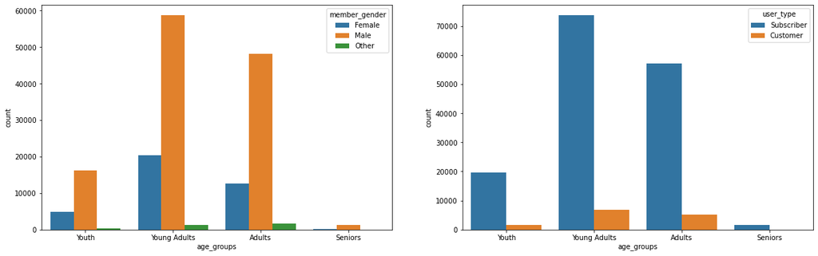

```python
plt.figure(figsize = [20, 6])
# first plot : distribution of rides by age_groups & member_gender
plt.subplot(1, 2, 1)
sb.countplot(data = df1, x = 'age_groups', hue = 'member_gender')
# second plot : distribution of rides by age_groups & user_type
plt.subplot(1, 2, 2)
sb.countplot(data = df1, x = 'age_groups', hue = 'user_type')
plt.show()
```

> Locking at the charts above, we find that :
> - Most riders were male young adults
> - Most members were subscriber young adults

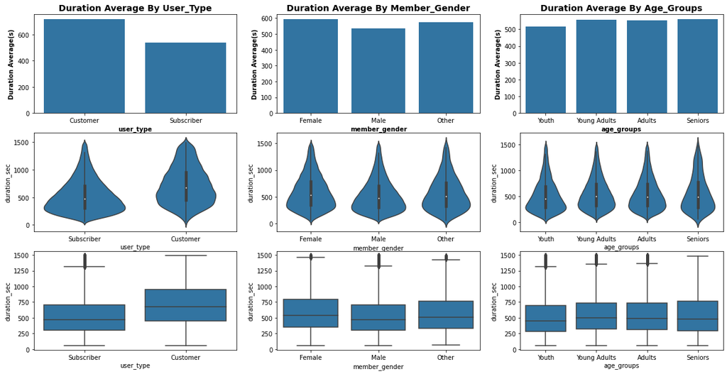

```python
# plot the categorical variables against duration
fig, ax = plt.subplots(ncols = 3, nrows = 3 , figsize = [20,10])

for i in range(len(categoric_vars)):
    var = categoric_vars[i]

    # barplot
    # define x and y for barplot
    x = df1.groupby(var).duration_sec.mean().index
    y = df1.groupby(var).duration_sec.mean()
    # plot x and y using seaborn.barplot
    sb.barplot(x, y, color=base_color, ax = ax[0,i])
    # add x label and format it
    ax[0,i].set_xlabel(f'{var}', fontsize=10, weight='bold')
    # add y label and format it, add unit if exist
    ax[0,i].set_ylabel('Duration Average(s)' , fontsize=10, weight='bold')
    # add title and format it
    ax[0,i].set_title(f'Duration Average by {var}'.title(), fontsize=14, weight='bold')

    # violinplot
    sb.violinplot(data = df1, x = var, y = 'duration_sec', ax = ax[1,i],
               color = base_color)
    # boxplot
    sb.boxplot(data = df1, x = var, y = 'duration_sec', ax = ax[2,i],
               color = base_color)


plt.show()
```

> Locking at the charts above, we find that :
> - The trip duration distribution is much narrower for subscribers compared to casual riders on the shorter/quicker trip end overall. It seems like subscribers have a more specific usage or targeted goal riding the bikes compared to customers who vary more and generally rented the bikes for longer.
> - Though not a huge difference, male riders tend to have shorter trips compared to female users, indicated by both a smaller median and shorter IQR
> - Age Groups have almost the same trip duration distribution.

Average Trip Duration on Weekdays

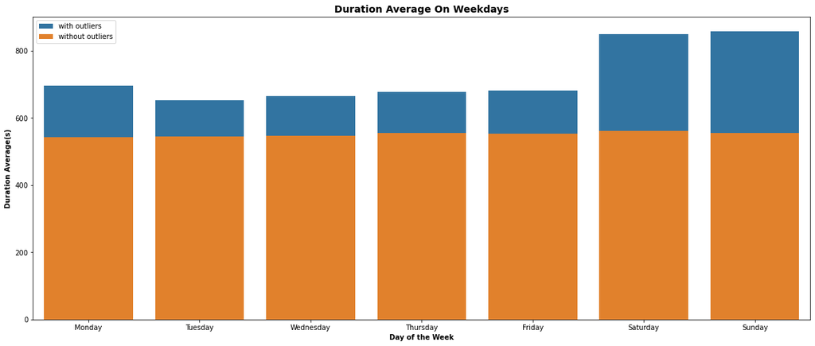

```python
plt.figure(figsize = [20, 8])
order = ['Monday', 'Tuesday', 'Wednesday', 'Thursday', 'Friday', 'Saturday', 'Sunday']

# Average Trip Duration on Weekdays (with outliers)
# define x and y for barplot, use df_clean( with outliers)
x = df_clean.groupby('start_day_week').duration_sec.mean().index
y = df_clean.groupby('start_day_week').duration_sec.mean()
# plot x and y using seaborn.barplot
sb.barplot(x, y, color=base_color, order=order, label='with outliers')

# Average Trip Duration on Weekdays (without outliers)
# define x and y for barplot, use df1 (without outliers)
x = df1.groupby('start_day_week').duration_sec.mean().index
y = df1.groupby('start_day_week').duration_sec.mean()
# plot x and y using seaborn.barplot
sb.barplot(x, y, color=sb.color_palette()[1], order=order, label='without outliers')

# add x label and format it
plt.xlabel('Day of the Week', fontsize=10, weight='bold')
# add y label and format it
plt.ylabel('Duration Average(s)' , fontsize=10, weight='bold')
# add title and format it
plt.title('Duration Average on Weekdays'.title(), fontsize=14, weight='bold')
# add legend
plt.legend()
```

> - We can see that when we remove the outliers, the ride duration average is the same all the week.
> - Taking in consideration the outliers, The riding trips are much shorter on Monday through Friday compared to weekends.It indicates a pretty stable and efficient usage of the sharing system on normal work days, while more casual flexible use on weekends.

Average Trip Duration at Hour of the day

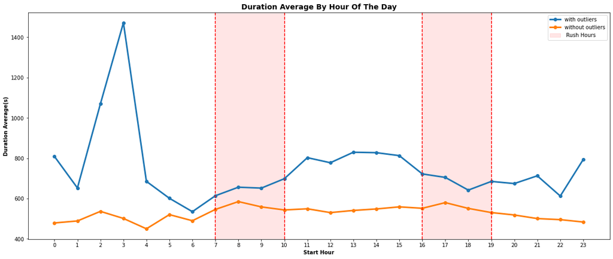

```python
plt.figure(figsize = [20, 8])

# Average Trip Duration at Hour of the day (with outliers)
# define x and y for pointplot, use df_clean( with outliers)
x = df_clean.groupby('start_hour').duration_sec.mean().index
y = df_clean.groupby('start_hour').duration_sec.mean()
# plot x and y using seaborn.pointplot
plt.plot(x, y,'go-', color=base_color, linewidth=3, label='with outliers')

# Average Trip Duration at Hour of the day (without outliers)
# define x and y for barplot, use df1 (without outliers)
x = df1.groupby('start_hour').duration_sec.mean().index
y = df1.groupby('start_hour').duration_sec.mean()
# plot x and y using seaborn.pointplot
plt.plot(x, y, 'go-', color=sb.color_palette()[1], linewidth=3, label='without outliers')

# add rush hours using axvline & axvspan
plt.axvline(x=7, ls='--', color='r')
plt.axvline(x=10, ls='--',color='r')
plt.axvspan(7, 10, alpha=0.1, color='red', label=' Rush Hours')
plt.axvline(x=16, ls='--', color='r')
plt.axvline(x=19, ls='--', color='r')
plt.axvspan(16, 19, alpha=0.1, color='red')

# add x label and format it
plt.xlabel('Start Hour', fontsize=10, weight='bold')
# add y label and format it
plt.ylabel('Duration Average(s)' , fontsize=10, weight='bold')
# add title and format it
plt.title('Duration Average by Hour of the day'.title(), fontsize=14, weight='bold')
# add legend
plt.legend()
#show all xticks
plt.xticks(x)

plt.show()
```

> the chart above shows that :
> - Ride duration average is smaller and more stable duraing the rush hours
> - The average usage time shown an increasing trend during normal hours

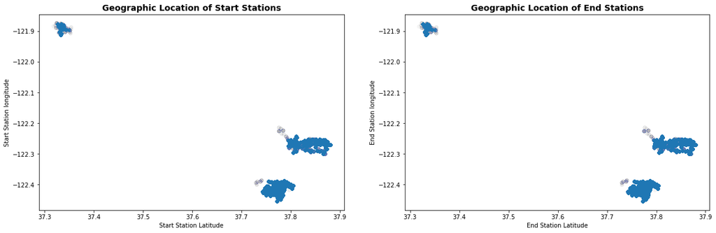

```python
plt.figure(figsize = [20, 6])

# plot geographic location of all start stations
plt.subplot(1, 2, 1)
plt.scatter(data = df_clean, x = 'start_station_latitude', y = 'start_station_longitude', alpha = 1/500);
plt.title('Geographic Location of Start Stations', fontsize=14, weight='bold');
plt.xlabel('Start Station Latitude');
plt.ylabel('Start Station longitude');

# plot geographic location of all end stations
plt.subplot(1, 2, 2)
plt.scatter(data = df_clean, x = 'end_station_latitude', y = 'end_station_longitude', alpha = 1/500);
plt.title('Geographic Location of End Stations', fontsize=14, weight='bold');
plt.xlabel('End Station Latitude');
plt.ylabel('End Station longitude');
```

> Locking at the charts above, we can see that there are three main areas of Station Locations.

### Talk about some of the relationships you observed in this part of the investigation. How did the feature(s) of interest vary with other features in the dataset?

> There are a lot more subscriber usage than customers, more male than female. The riding habit/pattern varies a lot between subscribers and customers : Subscribers use the bike sharing system for work, whereas customers tend to ride for fun for longer. shorter trips were on work days (Mon-Fri) and especially during rush hours (when going to work in the morning and getting off work in the afternoon).

### Did you observe any interesting relationships between the other features (not the main feature(s) of interest)?

> Start and end stations are located in three main georaphic zones.

## Multivariate Exploration

let's first find the relationship of ride duration with two categoric features in the same time:

- user_type & member_gender
- age_groups & member_gender
- age_groups & user_type

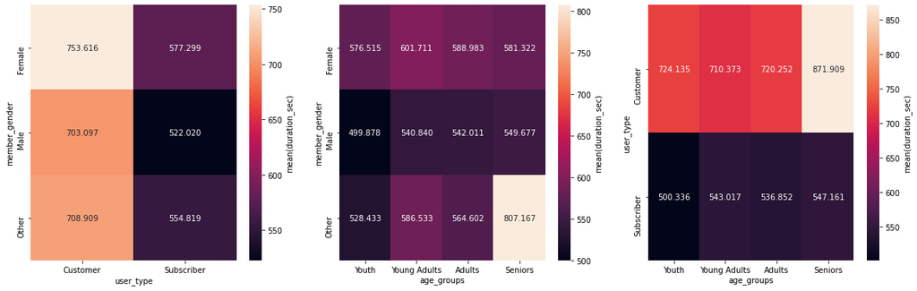

```python
plt.figure(figsize = [20, 6])

# plot mean duration by user_type & member_gender
plt.subplot(1, 3, 1)
cat_means = df1.groupby(['user_type', 'member_gender']).mean()['duration_sec']
cat_means = cat_means.reset_index(name = 'duration_avg')
cat_means = cat_means.pivot(index = 'member_gender', columns = 'user_type',
                            values = 'duration_avg')
sb.heatmap(cat_means, annot = True, fmt = '.3f',
           cbar_kws = {'label' : 'mean(duration_sec)'})

# plot mean duration by age_groups & member_gender
plt.subplot(1, 3, 2)
cat_means = df1.groupby(['age_groups', 'member_gender']).mean()['duration_sec']
cat_means = cat_means.reset_index(name = 'duration_avg')
cat_means = cat_means.pivot(index = 'member_gender', columns = 'age_groups',
                            values = 'duration_avg')
sb.heatmap(cat_means, annot = True, fmt = '.3f',
           cbar_kws = {'label' : 'mean(duration_sec)'})

# plot mean duration by age_groups & user_type
plt.subplot(1, 3, 3)
cat_means = df1.groupby(['age_groups', 'user_type']).mean()['duration_sec']
cat_means = cat_means.reset_index(name = 'duration_avg')
cat_means = cat_means.pivot(index = 'user_type', columns = 'age_groups',
                            values = 'duration_avg')
sb.heatmap(cat_means, annot = True, fmt = '.3f',
           cbar_kws = {'label' : 'mean(duration_sec)'})

plt.show()
```

We can plot the relationship between the four features above together : duration, user_type, member_gender and age_groups :

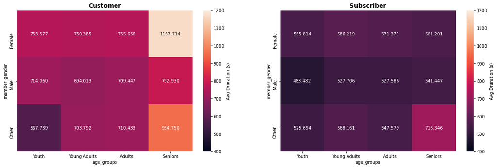

```python
# create new table contains mean duration for each user type, age_groups and memeber_gende
cat_means = df1.groupby(['user_type','age_groups', 'member_gender'], as_index=False).mean()[['user_type','age_groups', 'member_gender','duration_sec']]
cat_means = cat_means.pivot(index = 'member_gender', columns = ['user_type','age_groups'],
                            values = 'duration_sec')

plt.figure(figsize = [20, 6])

# first plot : Customer mean duration by age_groups & member_gender
plt.subplot(1, 2, 1)
sb.heatmap(cat_means['Customer'], vmin=400, vmax=1200, annot = True, fmt = '.3f',
           cbar_kws = {'label' : 'Avg Druration (s)'})
plt.title('Customer', fontsize=14, weight='bold')

# Second plot : Subscriber mean duration by age_groups & member_gender
plt.subplot(1, 2, 2)
sb.heatmap(cat_means['Subscriber'], vmin=400, vmax=1200, annot = True, fmt = '.3f',
           cbar_kws = {'label' : 'Avg Druration (s)'})
plt.title('Subscriber', fontsize=14, weight='bold')

plt.show()
```

> The charts above show clearly the relationship between the main feature **ride duration** and the categoric features. we can see, as we found before, that subscriber ride duration is smaller tha Customer. We find also that young male subcribers are the fastest riders and female senior customers are the slowest.

In the last part, I will focus on finding the variation of ride duration during weekdays and hours of day.

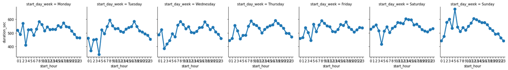

```python
df_week_hour = df1.groupby(['start_day_week','start_hour'], as_index=False).mean()
order = ['Monday', 'Tuesday', 'Wednesday', 'Thursday', 'Friday', 'Saturday', 'Sunday']

# plot for each day the variantio of mean duration by hour of day
g = sb.FacetGrid(data = df_week_hour, col= 'start_day_week', col_order=order)
g.map(sb.pointplot,'start_hour', 'duration_sec')

plt.show()
```

we can do the same as above using sb.heatmap :

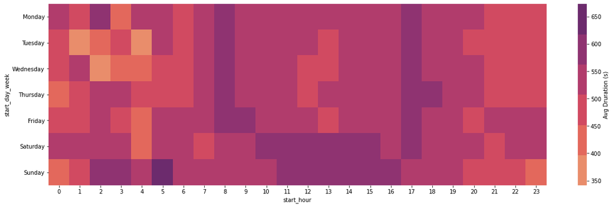

```python
# first put weekdays in order
order = ['Monday', 'Tuesday', 'Wednesday', 'Thursday', 'Friday', 'Saturday', 'Sunday']
df1['start_day_week'] = pd.Categorical(df1['start_day_week'],order)
df1.sort_values('start_day_week')

# create new table contains mean duration for each weekday and at each hour
cat_means = df1.groupby(['start_day_week', 'start_hour']).mean()['duration_sec']
cat_means = cat_means.reset_index(name = 'duration_avg')
cat_means = cat_means.pivot(index = 'start_day_week', columns = 'start_hour',

                            values = 'duration_avg')
# plot finding
plt.figure(figsize = [20, 6])
sb.heatmap(cat_means, cmap = sb.color_palette("flare"), fmt = '.3f',
           cbar_kws = {'label' : 'Avg Druration (s)'})
plt.show()
```

### Talk about some of the relationships you observed in this part of the investigation. Were there features that strengthened each other in terms of looking at your feature(s) of interest?

> This section essentially amplified the previous data topics of exploration through different visuals and adding in more variables to compare to other variables. Subscriber vs Customer mean duration was expanded upon through the use of age groups and member gender : The heatmap shows, as we found in the previous section, that subscriber ride duration is smaller tha Customer, young male subcribers are the fastest riders and female senior customers are the slowest.

### Were there any interesting or surprising interactions between features?

> Nothing out of the expected here. It was interesting to note that when removing outliers, the ride trips are longer during rush hours (espacialy at 8.am and 5.pm) from monday to friday and between 10.am and 4.pm during the weekend.